# ArchR

knitr::opts_chunk$set(cache = FALSE, autodep = TRUE, collapse = TRUE, message = FALSE)

ArchR takes as input aligned BAM or fragment files. These files are stored in the HDF5 file format (hierarchical data format version5). The HDF5 files are the constituent pieces of an ArchR analysis. They are called Arrow files. All Arrow files are grouped into a project, a compressed R data file. The Files are accessed in minimal chunks (parallel read and write operations). Therefore, in memory we do not have any large file sizes.

To select high quality celsl TSS enrichment scores are used.

#### Doublet detection-and-removal algorithm

Heterotypic doublets are identified by generating a collection of synthetic doublets. These synthetic doublets are projected into low-dimensional embeddings. Searching for nearest neighbours to the synthetic doublets we can identify doublets in the dataset. This outperforms the prediction of doublets using fragment number (ROC-AUC). (Compared to demuxlet as ground truth)

#### Dimensionality reduction

- two other algorithms:
  - latent semantic indexing (LSI) in Signac
  - landmark diffusion maps (LDM) in SnapATAC
- ArchR: optimized iterative LSI method
  - exhibits less susceptibility to batch effects
  - focuses on most variable features
  1. create a LSI REduction from a subset of the total cells
  2. linearly project the remaining cells into this subspace with LSI proejection (based on SVD)

### Load libraries

```r
library(ArchR)
#library(caret)
```

```r
inputFiles <- getTutorialData("Hematopoiesis")
```

```r
addArchRGenome("hg19")
```

```
## Setting default genome to Hg19.
```

Create Arrow Files

1. read accexxible fragments
2. calculate QC information for each cell (TSS enrichment scores and nucelosome info)
3. filter cells based on QC parameters
4. create genome-wide tile matrix using 500-bp bins
5. create GeneScoreMatrix using gene annotation

**TSS enrichment score** = signal to noise calculation The reads around a particular TSS are collected and aggregated to form a distribution of reads which is centered on th TSS. this distribution extends to 1000bp in both directions * we take the average read depth in the 100 bps at each end flank and calcualte a fold change at each position over that average read depth (total of 200bp of averaged data) * If there is a high read signal at TSS there will be an increase in signal towards the middle of the distribution * high signal means that the region is accessible * the signal value at the center of the distribution is the TSS enrichment metric

```r
ArrowFiles <- createArrowFiles(
  inputFiles = inputFiles,
  sampleNames = names(inputFiles),
  minTSS = 4, #Dont set this too high because you can always increase later
  minFrags = 1000, # minimum number of mapped fragments required
  addTileMat = TRUE,
  addGeneScoreMat = TRUE
)
```

```
## Using GeneAnnotation set by addArchRGenome(Hg19)!
## Using GeneAnnotation set by addArchRGenome(Hg19)!
```

```
## ArchR logging to : ArchRLogs/ArchR-createArrows-11d47c41baf1-Date-2022-01-31_Time-17-02-00.log
## If there is an issue, please report to github with logFile!
```

```
## Cleaning Temporary Files
```

```
## 2022-01-31 17:02:00 : Batch Execution w/ safelapply!, 0 mins elapsed.
```

```
## (scATAC_BMMC_R1 : 1 of 3) Checking if completed file exists!
```

```
## 2022-01-31 17:02:00 : (scATAC_BMMC_R1 : 1 of 3) Arrow Exists! Marking as completed since force = FALSE!, 0.001 mins elapsed.
```

```
## (scATAC_CD34_BMMC_R1 : 2 of 3) Checking if completed file exists!
```

```
## 2022-01-31 17:02:00 : (scATAC_CD34_BMMC_R1 : 2 of 3) Arrow Exists! Marking as completed since force = FALSE!, 0.002 mins elapsed.
```

```
## (scATAC_PBMC_R1 : 3 of 3) Checking if completed file exists!
```

```
## 2022-01-31 17:02:00 : (scATAC_PBMC_R1 : 3 of 3) Arrow Exists! Marking as completed since force = FALSE!, 0.002 mins elapsed.
```

```
## ArchR logging successful to : ArchRLogs/ArchR-createArrows-11d47c41baf1-Date-2022-01-31_Time-17-02-00.log
```

```r
# the arrow files object simply contains a character vector of arrow file paths
ArrowFiles
```

```
## [1] "scATAC_BMMC_R1.arrow"      "scATAC_CD34_BMMC_R1.arrow"
## [3] "scATAC_PBMC_R1.arrow"
```

### QC

1. the number of **unique nuclear fragments** (as opposed to mitochondrial fragments)
2. **signal-to-background ratio** -> if this is low this probably corresponds to dying cells where the entire genome allows random transposition
3. **fragment size distribution** -> since 147 bp are wrapped around a nucleosome it is expected that there are depletions of fragments of this length at regular intervals

### Inferring Doublets

Should be removed, because they can interfere with downstream analysis

```r
doubScores <- addDoubletScores(
  input = ArrowFiles,
  k = 10, #Refers to how many cells near a "pseudo-doublet" to count.
  knnMethod = "UMAP", #Refers to the embedding to use for nearest neighbor search.
  LSIMethod = 1
)
```

```
## ArchR logging to : ArchRLogs/ArchR-addDoubletScores-11d47fe66fc7-Date-2022-01-31_Time-17-02-01.log
## If there is an issue, please report to github with logFile!
```

```
## 2022-01-31 17:02:01 : Batch Execution w/ safelapply!, 0 mins elapsed.
```

```
## 2022-01-31 17:02:01 : scATAC_BMMC_R1 (1 of 3) :  Computing Doublet Statistics, 0 mins elapsed.
```

```
## scATAC_BMMC_R1 (1 of 3) : UMAP Projection R^2 = 0.98921
```

```
## scATAC_BMMC_R1 (1 of 3) : UMAP Projection R^2 = 0.98921
```

```
## 2022-01-31 17:04:19 : scATAC_CD34_BMMC_R1 (2 of 3) :  Computing Doublet Statistics, 2.297 mins elapsed.
```

```
## scATAC_CD34_BMMC_R1 (2 of 3) : UMAP Projection R^2 = 0.98962
```

```
## scATAC_CD34_BMMC_R1 (2 of 3) : UMAP Projection R^2 = 0.98962
```

```
## 2022-01-31 17:06:02 : scATAC_PBMC_R1 (3 of 3) :  Computing Doublet Statistics, 4.015 mins elapsed.
```

```
## scATAC_PBMC_R1 (3 of 3) : UMAP Projection R^2 = 0.97298
```

```
## scATAC_PBMC_R1 (3 of 3) : UMAP Projection R^2 = 0.97298
```

```
## ArchR logging successful to : ArchRLogs/ArchR-addDoubletScores-11d47fe66fc7-Date-2022-01-31_Time-17-02-01.log
```

### Create ArchRProject

An ArchR Project is initialized with some important attributes:

- ouput directory
- sample names
- `sampleColData` -> matrix containint data for each sample
- `cellColData` -> contains data associated with each cell
  - after using `addDoubletScore()` there will be a column for “Doublet Enrichment” and “Doublet Score”
- total number of cells (excluding doublets)
- median TSS score & median number of fragments across all cells and samples

```r
proj <- ArchRProject(
  ArrowFiles = ArrowFiles,
  outputDirectory = "ArchRVignette",
  copyArrows = TRUE#This is recommened so that you maintain an unaltered copy for later usage.
)
```

```
## Using GeneAnnotation set by addArchRGenome(Hg19)!
## Using GeneAnnotation set by addArchRGenome(Hg19)!
```

```
## Validating Arrows...
```

```
## Getting SampleNames...
```

[output not shown]

Cell Names:

```r
# cell names
proj$cellNames[1:5]
```

```
## [1] "scATAC_BMMC_R1#TTATGTCAGTGATTAG-1" "scATAC_BMMC_R1#AAGATAGTCACCGCGA-1"
## [3] "scATAC_BMMC_R1#GCATTGAAGATTCCGT-1" "scATAC_BMMC_R1#TATGTTCAGGGTTCCC-1"
## [5] "scATAC_BMMC_R1#TCCATCGGTCCCGTGA-1"
```

Sample Names:

```r
proj$Sample[1:5]
```

```
## [1] "scATAC_BMMC_R1" "scATAC_BMMC_R1" "scATAC_BMMC_R1" "scATAC_BMMC_R1"
## [5] "scATAC_BMMC_R1"
```

```r
length(proj$Sample)
```

```
## [1] 10660
```

For each cell there is a TSS enrichment score:

```r
proj$TSSEnrichment %>% head
```

```
## [1] 7.204 7.949 4.447 6.941 4.771 9.185
```

```r
quantile(proj$TSSEnrichment)
```

```
##      0%     25%     50%     75%    100%
##  4.1090 13.9255 16.8150 19.9285 41.9800
```

##### How to subset an ArchR project

- numerically

```r
# note that that only 100 cells are accessed
proj[1:100,]
```

[output not shown]

```
## class: ArchRProject
## outputDirectory: /omics/groups/OE0533/internal/katharina/scDoRI/ArchR/ArchRVignette
## samples(3): scATAC_BMMC_R1 scATAC_CD34_BMMC_R1 scATAC_PBMC_R1
## sampleColData names(1): ArrowFiles
## cellColData names(15): Sample TSSEnrichment ... DoubletEnrichment
##   BlacklistRatio
## numberOfCells(1): 100
## medianTSS(1): 10.794
## medianFrags(1): 10200.5
```

- by cell name

```r
proj[proj$cellNames[1:100], ]
```

[output not shown]

```
## class: ArchRProject
## outputDirectory: /omics/groups/OE0533/internal/katharina/scDoRI/ArchR/ArchRVignette
## samples(3): scATAC_BMMC_R1 scATAC_CD34_BMMC_R1 scATAC_PBMC_R1
## sampleColData names(1): ArrowFiles
## cellColData names(15): Sample TSSEnrichment ... DoubletEnrichment
##   BlacklistRatio
## numberOfCells(1): 100
## medianTSS(1): 10.794
## medianFrags(1): 10200.5
```

- keep specific samples

```r
idxSample <- BiocGenerics::which(proj$Sample %in% "scATAC_BMMC_R1")
cellsSample <- proj$cellNames[idxSample]
proj[cellsSample, ]
```

[output not shown]

```
## class: ArchRProject
## outputDirectory: /omics/groups/OE0533/internal/katharina/scDoRI/ArchR/ArchRVignette
## samples(3): scATAC_BMMC_R1 scATAC_CD34_BMMC_R1 scATAC_PBMC_R1
## sampleColData names(1): ArrowFiles
## cellColData names(15): Sample TSSEnrichment ... DoubletEnrichment
##   BlacklistRatio
## numberOfCells(1): 4932
## medianTSS(1): 15.2575
## medianFrags(1): 2771
```

- specific cutoff for TSS enrichment score

```r
idxPass <- which(proj$TSSEnrichment >= 8)
cellsPass <- proj$cellNames[idxPass]
proj[cellsPass, ]
```

[output not shown]

```
## class: ArchRProject
## outputDirectory: /omics/groups/OE0533/internal/katharina/scDoRI/ArchR/ArchRVignette
## samples(3): scATAC_BMMC_R1 scATAC_CD34_BMMC_R1 scATAC_PBMC_R1
## sampleColData names(1): ArrowFiles
## cellColData names(15): Sample TSSEnrichment ... DoubletEnrichment
##   BlacklistRatio
## numberOfCells(1): 10499
## medianTSS(1): 16.899
## medianFrags(1): 3042
```

```r
# What information does the vector of TSS enrichment contain?
class(proj$TSSEnrichment)
```

```
## [1] "numeric"
```

```r
length(proj$TSSEnrichment)
```

```
## [1] 10660
```

```r
length(proj$nFrags)
```

```
## [1] 10660
```

```r
getAvailableMatrices(proj)
```

```
## [1] "GeneScoreMatrix" "TileMatrix"
```

##### Obtaining columns from cellColData

- retrieve metadata columns, e.g. number of unique nuclear fragments per cell

```r
df <- getCellColData(proj, select = "nFrags")
df %>% head
```

```
## DataFrame with 6 rows and 1 column
##                                      nFrags
##                                   <numeric>
## scATAC_BMMC_R1#TTATGTCAGTGATTAG-1     26189
## scATAC_BMMC_R1#AAGATAGTCACCGCGA-1     20648
## scATAC_BMMC_R1#GCATTGAAGATTCCGT-1     18991
## scATAC_BMMC_R1#TATGTTCAGGGTTCCC-1     18296
## scATAC_BMMC_R1#TCCATCGGTCCCGTGA-1     17458
## scATAC_BMMC_R1#AGTTACGAGAACGTCG-1     17109
```

```r
dim(df)
```

```
## [1] 10660     1
```

- operations on a given column

```r
df <- getCellColData(proj, select = c("log10(nFrags)", "nFrags -1 "))

df %>% head
```

```
## DataFrame with 6 rows and 2 columns
##                                   log10(nFrags) nFrags -1
##                                       <numeric>  <numeric>
## scATAC_BMMC_R1#TTATGTCAGTGATTAG-1       4.41812      26188
## scATAC_BMMC_R1#AAGATAGTCACCGCGA-1       4.31488      20647
## scATAC_BMMC_R1#GCATTGAAGATTCCGT-1       4.27855      18990
## scATAC_BMMC_R1#TATGTTCAGGGTTCCC-1       4.26236      18295
## scATAC_BMMC_R1#TCCATCGGTCCCGTGA-1       4.24199      17457
## scATAC_BMMC_R1#AGTTACGAGAACGTCG-1       4.23322      17108
```

### Plot QC metrics

- TSS enrichment score = signa-to-background
- number of unique fragments -> cells with very few fragments do not have enough data to confidently analyze them
- in the plot areas with more points/cells are colored in orange, and areas with less points in blue, indicating the distribution of cell

```r
df <- getCellColData(proj, select = c("log10(nFrags)", "TSSEnrichment"))
df %>% head
```

```
## DataFrame with 6 rows and 2 columns
##                                   log10(nFrags) TSSEnrichment
##                                       <numeric>     <numeric>
## scATAC_BMMC_R1#TTATGTCAGTGATTAG-1       4.41812         7.204
## scATAC_BMMC_R1#AAGATAGTCACCGCGA-1       4.31488         7.949
## scATAC_BMMC_R1#GCATTGAAGATTCCGT-1       4.27855         4.447
## scATAC_BMMC_R1#TATGTTCAGGGTTCCC-1       4.26236         6.941
## scATAC_BMMC_R1#TCCATCGGTCCCGTGA-1       4.24199         4.771
## scATAC_BMMC_R1#AGTTACGAGAACGTCG-1       4.23322         9.185
```

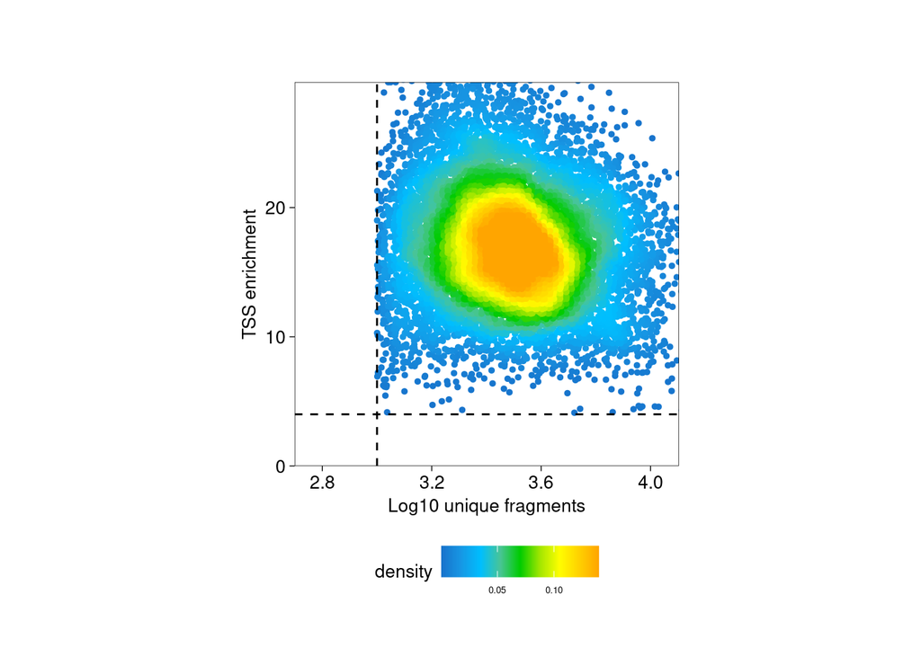

```r
p <- ggPoint(
  x = df[, 1], y = df[, 2],
  colorDensity = TRUE, # should the density of points on the plot be indicated by color?
  continuousSet = "sambaNight",
  xlabel = "Log10 unique fragments",
  ylabel = "TSS enrichment",
  xlim = c(log10(500), quantile(df[,1], probs = 0.99)),
  ylim = c(0, quantile(df[,2], probs = 0.99))
  ) + geom_hline(yintercept = 4, lty = "dashed") +
  geom_vline(xintercept = 3, lty = "dashed")
p
```